# Residuals

```r
library(DT)
library(tidyverse)
library(ggplot2)
library(latex2exp)

weather <- read_csv("../Data/WeatherData2.csv")
```

This document has been created to help students of linear regression better understand how it, including what residuals are, how the regression line is found, and how to assess how well the regression fits the data.

Note: For this document, the following data set will be used. View.

Before we can dive into explaining the former, the student must be familiar with the terminology associated with linear regressions. Click here if you need a refresher.

### Residuals

A residual is the distance from any data point to the regression line. This is what a residual looks like on a graph.

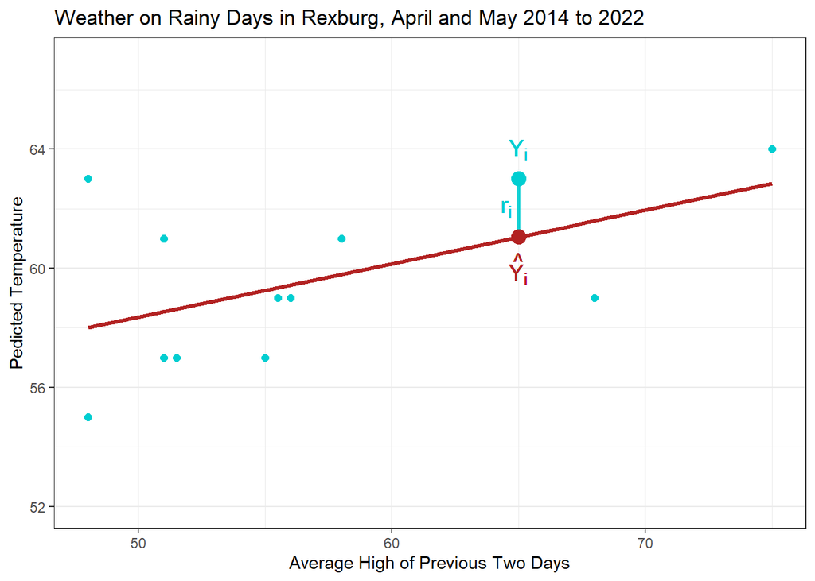

```r
ggplot(data=weather, aes(x=average, y=predict_temp)) +
  labs(x="Average High of Previous Two Days", y="Pedicted Temperature", title="Weather on Rainy Days in Rexburg, April and May 2014 to 2022") +
  geom_point(color="darkturquoise", size=2) +
  geom_smooth(method="lm", formula=y~x, se=F, color="firebrick", size=1.1) +
  theme_bw() +
  geom_segment(x=65, y=63, xend=65, yend=61.05, color="darkturquoise", size=1, linetype="solid", alpha=0.2) +
  ylim(52,67) +
  geom_point(x=65, y=63, color="darkturquoise", size=4) +
  geom_text(x=65, y=64, color="darkturquoise", size=5, label=TeX("$Y_i$")) +
  geom_point(x=65, y=61.05, color="firebrick", size=4) +
  geom_text(x=65, y=60, label=TeX("$\\hat{Y_i}$"), size=5, color="firebrick") +
  geom_text(x=64.5, y=62, label=TeX("$r_i$"), size=5, color="darkturquoise")
```

The value of a residual can be calculated as:

$$r_i = \underbrace{Y_i}_{\substack{\text{data} \\ \text{point}}} - \underbrace{\hat{Y_i}}_{\substack{\text{point on} \\ \text{regression line}}} \quad \text{(residual)}$$
where $Y_i$ is the observed value and $\hat{Y}_i$ is the predicted value. For example, in the graph above, the large dot represents a day where the actual high was 63°F, but the high predicted by the regression was 61°F. Thus that data point has a residual of 2°F. Pretty simple, huh?

Residuals show you if the observed data point is higher or lower than what is expected from the regression. Residuals are also used in diagnosing the assumptions of a linear regression.

The next tab shows how residuals can be used to assess the fit of the regression.

### Sums of Squares

“A square is a square,” is something both Brother Saunders and elementary school children alike are often caught saying (just teasin’). It sounds like a pointless statement, but it is very helpful in remembering what the upcoming terms mean.

#### SSE

Kind of like with standard deviation, you might be tempted to find the average of the residuals.Again, like standard deviation, you would always get zero as the “average residual”, because some are negative and some are positive - they cancel each other out. So the next best option is to square them.

If you square a single residual it looks like this.

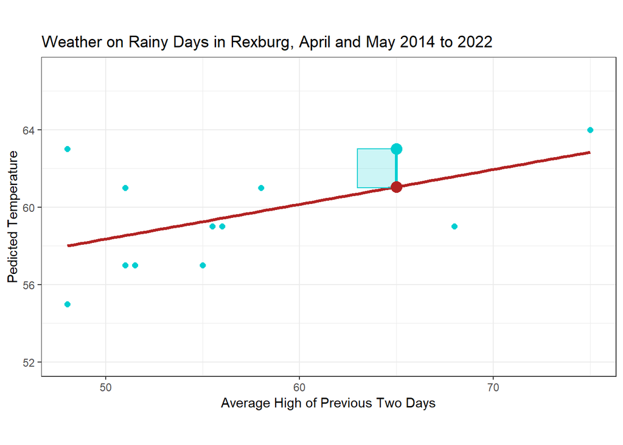

```r
ggplot(data=weather, aes(x=average, y=predict_temp)) +
  labs(x="Average High of Previous Two Days", y="Pedicted Temperature", title="Weather on Rainy Days in Rexburg, April and May 2014 to 2022") +
  geom_point(color="darkturquoise", size=2) +
  geom_point(x=65, y=63, color="darkturquoise", size=4) +
  geom_smooth(method="lm", formula=y~x, se=F, color="firebrick", size=1.1) +
  theme_bw() +
  annotate("rect", xmin=63, xmax=65, ymin=61, ymax=63, color="darkturquoise", fill="darkturquoise", alpha=0.2) +
  coord_fixed() +
  geom_segment(x=65, y=63, xend=65, yend=61.05, color="darkturquoise", size = 1.2, linetype="solid") +
  ylim(52,67) +
  geom_point(x=65, y=61.05, color="firebrick", size=4)
```

This is where the phrase “a square is a square” comes into play. The square of a residual ($r^2$) is a literal square! And if you square all residuals, you get a bunch of squares like so!

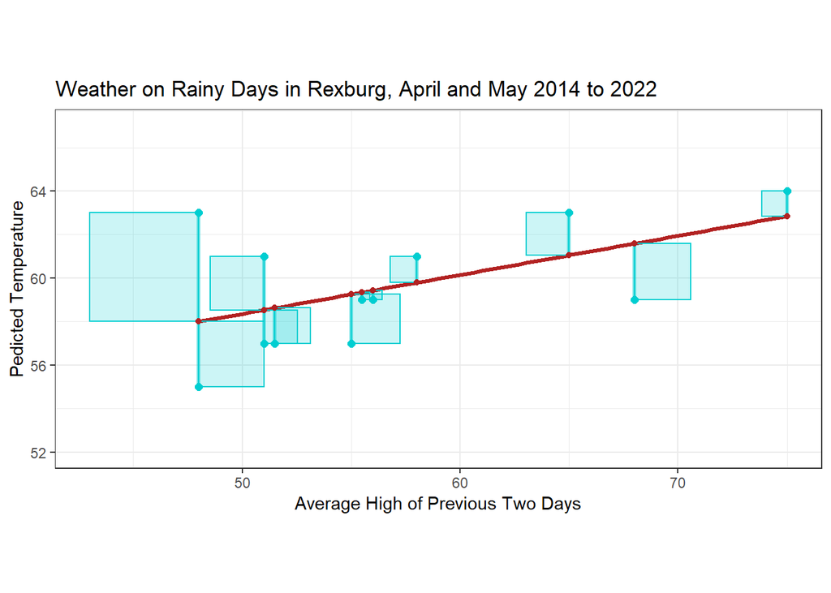

```r
res <- weather.lm$residuals

ggplot(data=weather, aes(x=average, y=predict_temp)) +
  labs(x="Average High of Previous Two Days", y="Pedicted Temperature", title="Weather on Rainy Days in Rexburg, April and May 2014 to 2022") +
  geom_point(color="darkturquoise", size=2) +
  geom_smooth(method="lm", formula=y~x, se=F, color="firebrick", size=1.1) +
  theme_bw() +
  annotate("rect", xmin=weather$average-res, xmax=weather$average, ymin=weather$predict_temp-res, ymax=weather$predict_temp, color="darkturquoise", fill="darkturquoise", alpha=0.2) +
  coord_fixed() +
  geom_segment(x=weather$average, y=weather$predict_temp, xend=weather$average, yend=weather$predict_temp-res, color="darkturquoise", size = 1.2, linetype="solid", alpha=0.5) +
  ylim(52,67) +
  geom_point(x=weather$average, y=predict(weather.lm, data.frame(average=weather$average)), color="firebrick", size=1.5)
```

This is why this tab is called Sum of Squared Errors (An error is similar to residual. For now, just know that they are somewhat interchangeable). If you added up (or summed) all the squares together into one big square, then you would have the total area of all the square errors, or Sum of Square Errors. From now on, we will just refer to this as SSE.

SSE is a good way to measure how far away in total the data ($Y_i$) are from the regression line ($\hat{Y_i}$). We calculate SSE as follows:

$$\text{SSE} = \sum_{i=1}^n \left(Y_i - \hat{Y}_i\right)^2$$

#### SSR

The Sum of Squares Regression, or SSR, is similar to SSE. Whereas SSE is the sum of the square of the distances between the **data** and the **regression**, SSR is the sum of the square of the distances between the **regression** ($\hat{Y_i}$) and the **average Y value** ($\bar{Y}$).

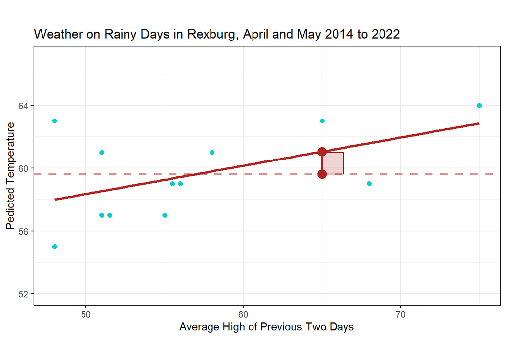

```r
ggplot(data=weather, aes(x=average, y=predict_temp)) +
  labs(x="Average High of Previous Two Days", y="Pedicted Temperature", title="Weather on Rainy Days in Rexburg, April and May 2014 to 2022") +
  geom_point(color="darkturquoise", size=2) +
  geom_point(x=65, y=61.05, color="firebrick", size=4) +
  geom_smooth(method="lm", formula=y~x, se=F, color="firebrick", size=1.1) +
  theme_bw() +
  annotate("rect", xmin=65, xmax=66.4, ymin=59.6, ymax=61, color="firebrick", fill="firebrick", alpha=0.2) +
  coord_fixed() +
  geom_segment(x=65, y=61, xend=65, yend=59.6, color="firebrick", size = 1.1, linetype="solid") +
  ylim(52,67) +
  geom_hline(yintercept=59.6, color="firebrick", size=1, linetype="dashed", alpha=0.5) +
  geom_point(x=65, y=59.6, color="firebrick", size=4)
```

Of course this is only one of the 12 squares needed for the actual SSR. Here is what the graph looks like with all the squares.

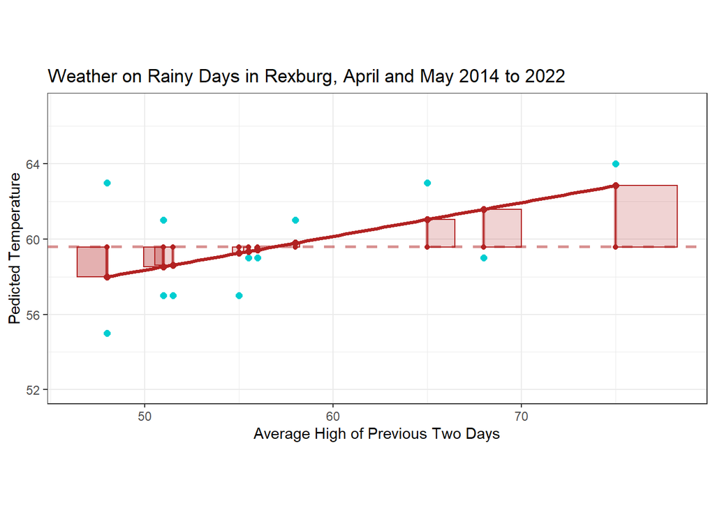

```r
diff=predict(weather.lm, data.frame(average=weather$average))-mean(weather$predict_temp)

ggplot(data=weather, aes(x=average, y=predict_temp)) +
  labs(x="Average High of Previous Two Days", y="Pedicted Temperature", title="Weather on Rainy Days in Rexburg, April and May 2014 to 2022") +
  geom_point(color="darkturquoise", size=2) +
  geom_smooth(method="lm", formula=y~x, se=F, color="firebrick", size=1.1) +
  theme_bw() +
  annotate("rect", xmin=weather$average, xmax=weather$average+diff, ymin=mean(weather$predict_temp), ymax=predict(weather.lm, data.frame(average=weather$average)), color="firebrick", fill="firebrick", alpha=0.2) +
  coord_fixed() +
  geom_segment(x=weather$average, y=predict(weather.lm, data.frame(average=weather$average)), xend=weather$average, yend=mean(weather$predict_temp), color="firebrick", size = 1.1, linetype="solid", alpha=0.5) +
  ylim(52,67) +
  geom_hline(yintercept=59.6, color="firebrick", size=1, linetype="dashed", alpha=0.5) +
  geom_point(x=weather$average, y=predict(weather.lm, data.frame(average=weather$average)), color="firebrick", size=2) +
  geom_point(x=weather$average, y=mean(weather$predict_temp), color="firebrick", size=1.5)
```

You can see that the squares on the graph are the squares of the difference between between the **regression** ($\hat{Y_i}$) and the **average Y value** ($\bar{Y}$). And that’s where the name comes from. Sum of Squares Regression. It is the sum of the squares associated with the regression. The SSR can be calculated as follows:

$$\text{SSR} = \sum_{i=1}^n \left(\hat{Y}_i - \bar{Y}\right)^2$$

One way to think of SSR is that it is the variability that the regression was able to “explain away”. This is is going to become an important concept that we will come back to later.

#### SSTO

SSTO stands for Total Sum of Squares. It is the sum of the squares of the differences between the **data** ($Y_i$) and the **mean** ($\hat{Y}$).

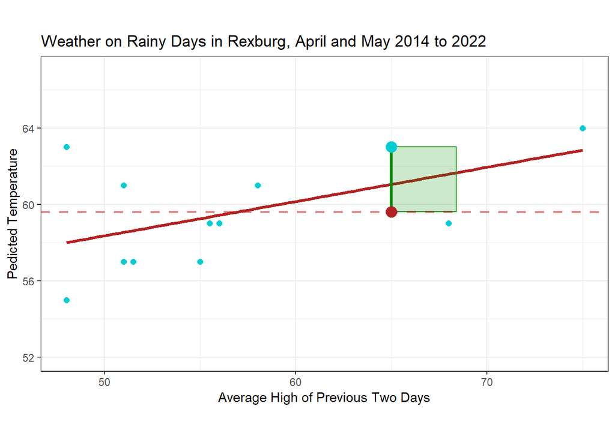

```r
ggplot(data=weather, aes(x=average, y=predict_temp)) +
  labs(x="Average High of Previous Two Days", y="Pedicted Temperature", title="Weather on Rainy Days in Rexburg, April and May 2014 to 2022") +
  geom_point(color="darkturquoise", size=2) +
  geom_smooth(method="lm", formula=y~x, se=F, color="firebrick", size=1.1) +
  theme_bw() +
  annotate("rect", xmin=65, xmax=68.4, ymin=59.6, ymax=63, color="green4", fill="green4", alpha=0.2) +
  coord_fixed() +
  geom_segment(x=65, y=63, xend=65, yend=59.6, color="green4", size = 1.1, linetype="solid") +
  ylim(52,67) +
  geom_hline(yintercept=59.6, color="firebrick", size=1, linetype="dashed", alpha=0.5) +
  geom_point(x=65, y=63, color="darkturquoise", size=4) +
  geom_point(x=65, y=59.6, color="firebrick", size=4)
```

And again, this is only part of the SSTO. To get all of it, we have to draw all the squares and sum them together.

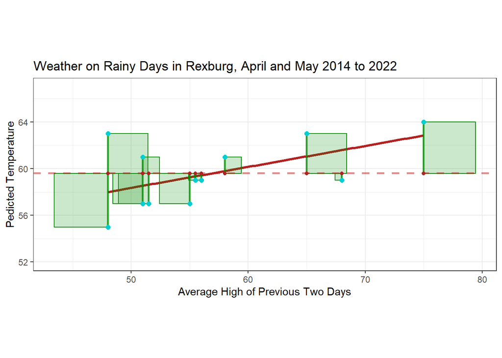

```r
diff2 <- weather$predict_temp-mean(weather$predict_temp)

ggplot(data=weather, aes(x=average, y=predict_temp)) +
  labs(x="Average High of Previous Two Days", y="Pedicted Temperature", title="Weather on Rainy Days in Rexburg, April and May 2014 to 2022") +
  geom_smooth(method="lm", formula=y~x, se=F, color="firebrick", size=1.1) +
  theme_bw() +
  annotate("rect", xmin=weather$average, xmax=weather$average+diff2, ymin=weather$predict_temp-diff2, ymax=weather$predict_temp, color="green4", fill="green4", alpha=0.2) +
  coord_fixed() +
  geom_segment(x=weather$average, y=weather$predict_temp, xend=weather$average, yend=mean(weather$predict_temp), color="green4", size = 1.1, linetype="solid", alpha=0.5) +
  ylim(52,67) +
  geom_hline(yintercept=59.6, color="firebrick", size=1, linetype="dashed", alpha=0.5) +
  geom_point(color="darkturquoise", size=2) +
  geom_point(x=weather$average, y=mean(weather$predict_temp), color="firebrick", size=1.5)
```

Now this is the full picture of SSTO. It is essentially the total variability of the data, and can be calculated as $SSR + SSE$. There is also a more formal way to calculate it:

$$\text{SSTO} = \sum_{i=1}^n \left(Y_i - \bar{Y}\right)^2$$

### Comparing Sums of Squares

So now we have learned about the three sums of squares. It would be helpful to see all three of them on a graph at once.

We will only draw the three squares for one data point so it doesn’t get too confusing; but just remember that this graphical depiction is incomplete without the squares for all the data.

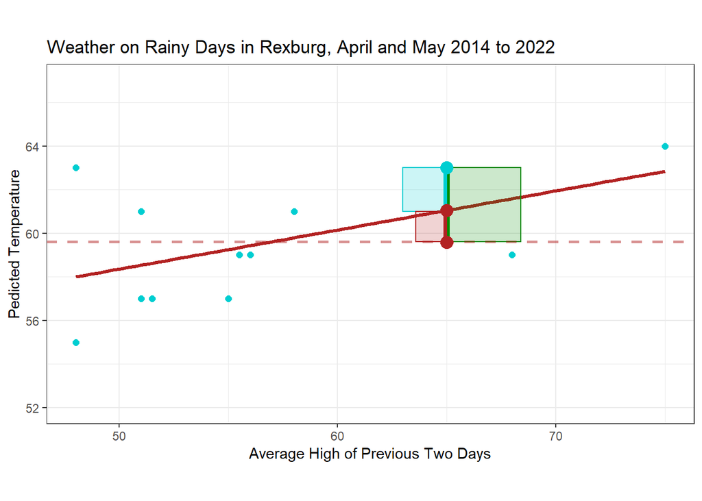

```r
ggplot(data=weather, aes(x=average, y=predict_temp)) +
  labs(x="Average High of Previous Two Days", y="Pedicted Temperature", title="Weather on Rainy Days in Rexburg, April and May 2014 to 2022") +
  geom_point(color="darkturquoise", size=2) +
  geom_smooth(method="lm", formula=y~x, se=F, color="firebrick", size=1.1) +
  theme_bw() +
  annotate("rect", xmin=65, xmax=68.4, ymin=59.6, ymax=63, color="green4", fill="green4", alpha=0.2) +
  geom_segment(x=65.08, y=63, xend=65.08, yend=59.6, color="green4", size = 1.1, linetype="solid") +
  annotate("rect", xmin=63, xmax=65, ymin=61, ymax=63, color="darkturquoise", fill="darkturquoise", alpha=0.2) +
  geom_segment(x=64.92, y=63, xend=64.92, yend=61.05, color="darkturquoise", size = 1.2, linetype="solid") +
  annotate("rect", xmin=65, xmax=63.6, ymin=59.6, ymax=61, color="firebrick", fill="firebrick", alpha=0.2) +
  geom_segment(x=64.92, y=61, xend=64.92, yend=59.6, color="firebrick", size = 1.1, linetype="solid") +
  geom_point(x=65, y=63, color="darkturquoise", size=4) +
  coord_fixed() +
  ylim(52,67) +
  geom_hline(yintercept=59.6, color="firebrick", size=1, linetype="dashed", alpha=0.5) +
  geom_point(x=65, y=predict(weather.lm, data.frame(average=65)), color="firebrick", size=4) +
  geom_point(x=65, y=mean(weather$predict_temp), color="firebrick", size=4)
```

Now after looking at this graph you might be a bit confused at a statement made earlier. $SSE + SSR = SSTO$ (or on the graph it would be blue + red = green). It’s easy to tell that those don’t add up. But that’s because we’re only looking at one data point. For it to be a true *sum*, the three squares have to be shown for all 12 data points.

In the next section, we will learn how to use the three sums of squares to calculate how well the regression fits the data.

### R^2

You can rearrange the equation relating the three sums as follows:

$$SSE + SSR = SSTO$$
$$SSTO - SSR = SSE$$

This is important, because another way to think of the three sums is SSTO is the **total** variability, SSR is the **known** variability, and SSE is the **unknown** variability. That is why earlier it was stated that SSR is the variability that was “explained away”, and we are then left with the “unknown” variability, or $SSE$.

Because SSR is the **known** variability, we can divide it by SSTO, the **total** variability, to find what portion of the variability is explained by the regression. This is called $R^2$:

$$R^2 = \frac{SSR}{SSTO} = 1 - \frac{SSE}{SSTO}$$

The formal definition of $R^2$ is the proportion of the total variation explained by the regression. The highest $R^2$ can be is 1 (because you can’t have more explained variation than exists), and the lowest is 0 (because you can’t have more unexplained variation than exists).

Here are the sums of squares and $R^2$ vlaues for the `weather` data that we have been looking at.

[output not shown]

```r
sse <- sum( (weather.lm$residuals)^2 )
ssr <- sum( (weather.lm$fit - mean(weather$predict_temp))^2 )
ssto <- sum( (weather$predict_temp - mean(weather$predict_temp))^2 )
r2 <- ssr/ssto
```

It should be noted that this is not a *part* of SSTO, SSR, and SSE that corresponds to a single data point. This is the actual *sum* of the three different squares that have been described.

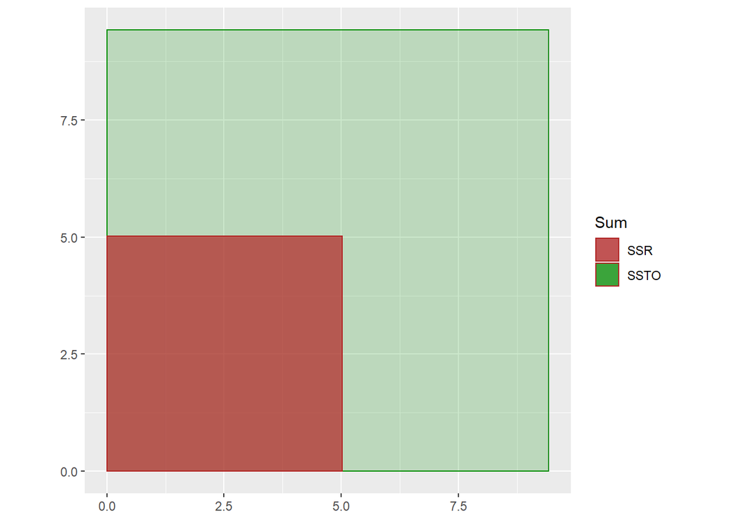

```r
ggplot() +
  geom_rect(aes(xmin=0, xmax=9.43, ymin=0, ymax=9.43, fill="SSTO"), color="green4", alpha=0.2) +
  geom_rect(aes(xmin=0, xmax=5.02, ymin=0, ymax=5.02, fill="SSR"), color="firebrick", alpha=0.7) +
  coord_fixed() +
  scale_fill_manual(values=c("firebrick","green4"), name="Sum")
```